# Scientific Computing: Data Exploration & Preparation

In this part we will work on a really classical example: the Titanic dataset data exploration and preparation.

# I. Data exploration

We first load the dataset with pandas:

```python
import numpy as np
import pandas as pd

df = pd.read_csv('titanic.csv')
df.head()
```

|  | PassengerId | Survived | Pclass | Name | Sex | Age | SibSp | Parch | Ticket | Fare | Cabin | Embarked |
| --- | --- | --- | --- | --- | --- | --- | --- | --- | --- | --- | --- | --- |
| 0 | 1 | 0 | 3 | Braund, Mr. Owen Harris | male | 22.0 | 1 | 0 | A/5 21171 | 7.2500 | NaN | S |
| 1 | 2 | 1 | 1 | Cumings, Mrs. John Bradley (Florence Briggs Th... | female | 38.0 | 1 | 0 | PC 17599 | 71.2833 | C85 | C |
| 2 | 3 | 1 | 3 | Heikkinen, Miss. Laina | female | 26.0 | 0 | 0 | STON/O2. 3101282 | 7.9250 | NaN | S |
| 3 | 4 | 1 | 1 | Futrelle, Mrs. Jacques Heath (Lily May Peel) | female | 35.0 | 1 | 0 | 113803 | 53.1000 | C123 | S |
| 4 | 5 | 0 | 3 | Allen, Mr. William Henry | male | 35.0 | 0 | 0 | 373450 | 8.0500 | NaN | S |

We can then have a quick look at the columns, and data types:

```python
df.info()
```

```
<class 'pandas.core.frame.DataFrame'>
RangeIndex: 891 entries, 0 to 890
Data columns (total 12 columns):
PassengerId    891 non-null int64
Survived       891 non-null int64
Pclass         891 non-null int64
Name           891 non-null object
Sex            891 non-null object
Age            714 non-null float64
SibSp          891 non-null int64
Parch          891 non-null int64
Ticket         891 non-null object
Fare           891 non-null float64
Cabin          204 non-null object
Embarked       889 non-null object
dtypes: float64(2), int64(5), object(5)
memory usage: 83.7+ KB
```

We have missing data here... We will handle them later

We would like to have a visual representation of our data. To do so, we can use **matplotlib**, a basic and widely used data visualization library.

To use most of the dataviz methods in matplotlib, you can import the library like this:

```python
import matplotlib.pyplot as plt
```

For example we want to have a visual representation of the gender proportion.

- How can you get the number of samples of each class (male, female)?
- What kind of plot would you use to display such information?

```python
# You can get the information with a groupby
df.groupby(['Sex'])['Sex'].count()
```

```
Sex
female    314
male      577
Name: Sex, dtype: int64
```

```python
# Even easier
df['Sex'].value_counts()
```

```
male      577
female    314
Name: Sex, dtype: int64
```

Now we can display a barplot, using `plt.bar()`

```
[]
```

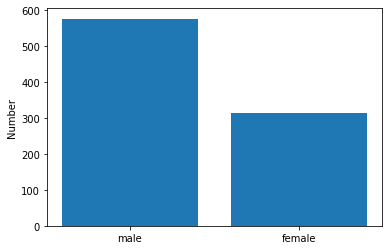

```python
plt.bar(df['Sex'].value_counts().index, df['Sex'].value_counts())
plt.ylabel('Number')
plt.plot()
```

We would now have a look at the age distribution. What kind of visualization would you need to display a distribution?

We can use `plt.hist()` to make and plot a histogram:

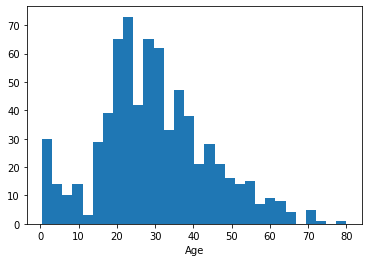

```python
plt.hist(df['Age'], bins=30)
plt.xlabel('Age')
plt.show()
```

We also could see the distribution for both male and female, using filtering.

In this case, we would need a legend, to be printed with `plt.legend()`, and we may want to add transparency to our histograms, with the parameter `alpha`.

```
[]
```

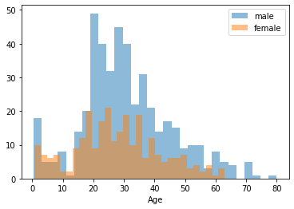

```python
plt.hist(df[df['Sex']=='male']['Age'], bins=30, label='male', alpha=0.5)
plt.hist(df[df['Sex']=='female']['Age'], bins=30, label='female', alpha=0.5)
plt.xlabel('Age')
plt.legend()
plt.plot()
```

There are many more visualization tools:

- `plt.plot()` for the classical plot, useful when ploting a curve
- `plt.scatter()` for a scatter plot, useful for multivariate visualization
- `plt.boxplot()` for a boxplot
- ...

Choosing the right visualization is critical, as the displayed information may not be relevant with another one...

We would like to have a look at the correlation of the age and the fare, how would you represent such information?

```
[]
```

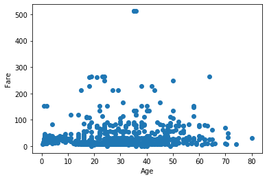

```python
plt.scatter(df['Age'], df['Fare'])
plt.xlabel('Age')
plt.ylabel('Fare')
plt.plot()
```

For more advanced visualization, one can also use **seaborn**.

You can import it with:

```
import seaborn as sns
```

One very nice feature with seaborn (among many others) is the `pairplot()`: it allows to show directly the distribution of each feature, and the correlations with others.

**Warning**: with large datasets, it may take a while to compute!

[output not shown]

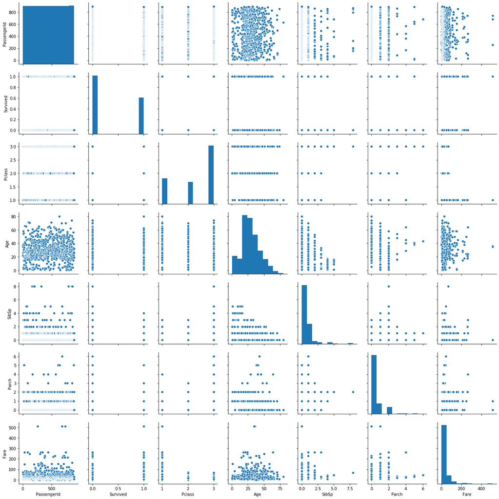

```python
import seaborn as sns

sns.pairplot(df)
plt.show()
```

What other features and correlations would you visualize before going forward?

**Exercise:**

In case of emergency, we are used to say 'children and women first', it that true here?

# II. Data cleaning

We now need to prepare the data, meaning the following steps:

- Select relevant features
- Handle missing data, duplicates, outliers
- Preprocess the data (both categorical and quantitative)
- Possibly, make feature engineering

## II.1 Features selection

We might not need to keep all the given features, let's have a look at what we can drop:

```python
df.head()
```

|  | PassengerId | Survived | Pclass | Name | Sex | Age | SibSp | Parch | Ticket | Fare | Cabin | Embarked |
| --- | --- | --- | --- | --- | --- | --- | --- | --- | --- | --- | --- | --- |
| 0 | 1 | 0 | 3 | Braund, Mr. Owen Harris | male | 22.0 | 1 | 0 | A/5 21171 | 7.2500 | NaN | S |
| 1 | 2 | 1 | 1 | Cumings, Mrs. John Bradley (Florence Briggs Th... | female | 38.0 | 1 | 0 | PC 17599 | 71.2833 | C85 | C |
| 2 | 3 | 1 | 3 | Heikkinen, Miss. Laina | female | 26.0 | 0 | 0 | STON/O2. 3101282 | 7.9250 | NaN | S |
| 3 | 4 | 1 | 1 | Futrelle, Mrs. Jacques Heath (Lily May Peel) | female | 35.0 | 1 | 0 | 113803 | 53.1000 | C123 | S |
| 4 | 5 | 0 | 3 | Allen, Mr. William Henry | male | 35.0 | 0 | 0 | 373450 | 8.0500 | NaN | S |

Do you see columns that won't help predict the survival probability of a passenger? Or columns that might be difficult to handle properly?

Let's remove them.

```python
df = df.drop(columns=['PassengerId', 'Ticket'])
```

## II.2 Missing data

As previously stated, there is missing data:

```python
df.info()
```

```
<class 'pandas.core.frame.DataFrame'>
RangeIndex: 891 entries, 0 to 890
Data columns (total 10 columns):
Survived    891 non-null int64
Pclass      891 non-null int64
Name        891 non-null object
Sex         891 non-null object
Age         714 non-null float64
SibSp       891 non-null int64
Parch       891 non-null int64
Fare        891 non-null float64
Cabin       204 non-null object
Embarked    889 non-null object
dtypes: float64(2), int64(4), object(4)
memory usage: 69.7+ KB
```

How to deal with missing data?

There are several simplistic approaches:

- drop the entire column with `.drop()`: let's do that for the `'Cabin'` column
- drop the samples with missing data with `.dropna()`: let's do that for the `'Embarked'` column
- fill the data with `.fillna()`: let's do that for the `'Age'` columnµ

```python
# Drop the Cabin column
df = df.drop(columns=['Cabin'])

# Drop the two lines with missing Embarked
df = df.dropna(subset=["Embarked"])

# Fill the data without age with mean age
df['Age'] = df['Age'].fillna(df['Age'].mean())
```

Let's check again our dataset with `.info()`: we now have 889 lines, and no missing data!

```python
df.info()
```

```
<class 'pandas.core.frame.DataFrame'>
Int64Index: 889 entries, 0 to 890
Data columns (total 9 columns):
Survived    889 non-null int64
Pclass      889 non-null int64
Name        889 non-null object
Sex         889 non-null object
Age         889 non-null float64
SibSp       889 non-null int64
Parch       889 non-null int64
Fare        889 non-null float64
Embarked    889 non-null object
dtypes: float64(2), int64(4), object(3)
memory usage: 69.5+ KB
```

## II.3 Duplicates

One can check if there are duplicates in the data: be careful, some duplicates have to be kept!

```python
df.duplicated().sum()
```

```
0
```

We don't have duplicates here, but if we did we could have removed them with the method `.drop_duplicates()`

## II.4 Outliers

In some datasets, there can be outliers: data that do not make sense!

For example, broken sensor, misfilled information (a person have 220 years instead of 22...), and so on... Not all outliers have to be removed!

# III. Data preparation

There are two main types of data:

- Categorical data: both binary and non-binary
- Continuous data

In our dataset, can you tell what columns belong to which category?

```python
df.head()
```

|  | Survived | Pclass | Name | Sex | Age | SibSp | Parch | Fare | Embarked |
| --- | --- | --- | --- | --- | --- | --- | --- | --- | --- |
| 0 | 0 | 3 | Braund, Mr. Owen Harris | male | 22.0 | 1 | 0 | 7.2500 | S |
| 1 | 1 | 1 | Cumings, Mrs. John Bradley (Florence Briggs Th... | female | 38.0 | 1 | 0 | 71.2833 | C |
| 2 | 1 | 3 | Heikkinen, Miss. Laina | female | 26.0 | 0 | 0 | 7.9250 | S |
| 3 | 1 | 1 | Futrelle, Mrs. Jacques Heath (Lily May Peel) | female | 35.0 | 1 | 0 | 53.1000 | S |
| 4 | 0 | 3 | Allen, Mr. William Henry | male | 35.0 | 0 | 0 | 8.0500 | S |

Those data have to be preprocessed differently. How would you preprocess those kind of data?

## III.1 Categorical data

Categorical data has to be one-hot-encoded: meaning every class has to be transformed into 0 and 1.

We can do that with the pandas function `pd.get_dummies()`

```python
pd.get_dummies(df['Sex']).head()
```

|  | female | male |
| --- | --- | --- |
| 0 | 0 | 1 |
| 1 | 1 | 0 |
| 2 | 1 | 0 |
| 3 | 1 | 0 |
| 4 | 0 | 1 |

This transformed the strings `'male'` and `'female'` into `0` or `1`.

But isn't there redundancy in the information here? We can remove one column automatically with the option `drop_first=True`:

```python
pd.get_dummies(df['Sex'], drop_first=True).head()
```

|  | male |
| --- | --- |
| 0 | 1 |
| 1 | 0 |
| 2 | 0 |
| 3 | 0 |
| 4 | 1 |

So that now we have well encoded our gender attribute to a binary variable.

What about non-binary categorical data?

How can we replace the `'Embarked'` column (being `C`, `S` or `Q`) with only 0 and 1?

```python
pd.get_dummies(df['Embarked']).tail()
```

|  | C | Q | S |
| --- | --- | --- | --- |
| 886 | 0 | 0 | 1 |
| 887 | 0 | 0 | 1 |
| 888 | 0 | 0 | 1 |
| 889 | 1 | 0 | 0 |
| 890 | 0 | 1 | 0 |

Here, using again the function `get_dummies()`, we replaced `C`, `S` and `Q` with one-hot-encoding, meaning:

- `C` is now replaced by `(1, 0, 0)`
- `Q` is now replaced by `(0, 1, 0)`
- `S` is now replaced by `(0, 0, 1)`

Again, isn't this redundant? If this is not `C` nor `Q`, then this has to be `S`, right?

We can redo the `drop_first=True` trick to remove one columns and avoid redundancy:

```python
pd.get_dummies(df['Embarked'], drop_first=True).tail()
```

|  | Q | S |
| --- | --- | --- |
| 886 | 0 | 1 |
| 887 | 0 | 1 |
| 888 | 0 | 1 |
| 889 | 0 | 0 |
| 890 | 1 | 0 |

Now, we can preprocess all the categorical data in one line using the `get_dummies()` function. We first need to list all the categorical columns:

```python
categorical_columns = ['Sex', 'Embarked']
```

Then we can process them with `get_dummies()`:

```python
dummies = pd.get_dummies(df[categorical_columns], drop_first=True)
dummies.tail()
```

|  | Sex_male | Embarked_Q | Embarked_S |
| --- | --- | --- | --- |
| 886 | 1 | 0 | 1 |
| 887 | 0 | 0 | 1 |
| 888 | 0 | 0 | 1 |
| 889 | 1 | 0 | 0 |
| 890 | 1 | 1 | 0 |

## III.2 Quantitative data

Now we can play with quantitative data.

Let's have a look at the range of the values:

```python
df.describe()
```

|  | Survived | Pclass | Age | SibSp | Parch | Fare |
| --- | --- | --- | --- | --- | --- | --- |
| count | 889.000000 | 889.000000 | 889.000000 | 889.000000 | 889.000000 | 889.000000 |
| mean | 0.382452 | 2.311586 | 29.642093 | 0.524184 | 0.382452 | 32.096681 |
| std | 0.486260 | 0.834700 | 12.968346 | 1.103705 | 0.806761 | 49.697504 |
| min | 0.000000 | 1.000000 | 0.420000 | 0.000000 | 0.000000 | 0.000000 |
| 25% | 0.000000 | 2.000000 | 22.000000 | 0.000000 | 0.000000 | 7.895800 |
| 50% | 0.000000 | 3.000000 | 29.642093 | 0.000000 | 0.000000 | 14.454200 |
| 75% | 1.000000 | 3.000000 | 35.000000 | 1.000000 | 0.000000 | 31.000000 |
| max | 1.000000 | 3.000000 | 80.000000 | 8.000000 | 6.000000 | 512.329200 |

Some columns range from 1 to 3 (`Pclass`), while others climb up to 512 (`Fare`).

But we want to make sure all of those columns are considered to be at the same level: we need to rescale the data.

What strategies of rescaling can you imagine?

```python
quantitative_columns = ['Pclass', 'Age', 'SibSp', 'Parch', 'Fare']

scaled = (df[quantitative_columns] - df[quantitative_columns].mean())/df[quantitative_columns].std()

scaled.describe()
```

|  | Pclass | Age | SibSp | Parch | Fare |
| --- | --- | --- | --- | --- | --- |
| count | 8.890000e+02 | 8.890000e+02 | 8.890000e+02 | 8.890000e+02 | 8.890000e+02 |
| mean | -2.677523e-16 | 8.220396e-15 | -1.998152e-17 | -8.791867e-17 | 7.033494e-16 |
| std | 1.000000e+00 | 1.000000e+00 | 1.000000e+00 | 1.000000e+00 | 1.000000e+00 |
| min | -1.571327e+00 | -2.253340e+00 | -4.749317e-01 | -4.740590e-01 | -6.458409e-01 |
| 25% | -3.732912e-01 | -5.892881e-01 | -4.749317e-01 | -4.740590e-01 | -4.869637e-01 |
| 50% | 8.247444e-01 | 7.944629e-15 | -4.749317e-01 | -4.740590e-01 | -3.549973e-01 |
| 75% | 8.247444e-01 | 4.131527e-01 | 4.311076e-01 | -4.740590e-01 | -2.206712e-02 |
| max | 8.247444e-01 | 3.883140e+00 | 6.773383e+00 | 6.963090e+00 | 9.663111e+00 |

Now all our quantitative features are centered on 0 and have a standard deviation of 1.

## III.3 Feature Engineering

Sometimes, it might be useful to perform feature engineering: this is the art of creating new features!

In our example, we did not use at all the `Name` feature: how could we use it wisely?

```python
df['Name'].head(10)
```

```
0                              Braund, Mr. Owen Harris
1    Cumings, Mrs. John Bradley (Florence Briggs Th...
2                               Heikkinen, Miss. Laina
3         Futrelle, Mrs. Jacques Heath (Lily May Peel)
4                             Allen, Mr. William Henry
5                                     Moran, Mr. James
6                              McCarthy, Mr. Timothy J
7                       Palsson, Master. Gosta Leonard
8    Johnson, Mrs. Oscar W (Elisabeth Vilhelmina Berg)
9                  Nasser, Mrs. Nicholas (Adele Achem)
Name: Name, dtype: object
```

We would keep the title for example, and see what are the existing titles in our dataset.

We can do that using the pandas method `.str` and `.split()`:

```python
df['Title']= df['Name'].str.split(' ').str[1]
df['Title'].value_counts()
```

```
Mr.             502
Miss.           178
Mrs.            120
Master.          40
Dr.               7
Rev.              6
y                 4
Planke,           3
Impe,             3
Gordon,           2
Col.              2
Mlle.             2
Major.            2
Melkebeke,        1
Ms.               1
Jonkheer.         1
der               1
Pelsmaeker,       1
Steen,            1
Shawah,           1
Cruyssen,         1
Mme.              1
Mulder,           1
Walle,            1
Billiard,         1
Velde,            1
Messemaeker,      1
Don.              1
Carlo,            1
Capt.             1
the               1
Name: Title, dtype: int64
```

We could split that into several classes: `Mr.`, `Miss.`, `Mrs.`, `Master.` and `Others` for example.

```python
df.loc[(df['Title']!='Mr.') & (df['Title']!='Miss.') & (df['Title']!='Mrs.') & (df['Title']!='Master.'), 'Title'] = 'Others'
df['Title'].value_counts()
```

```
Mr.        502
Miss.      178
Mrs.       120
Others      49
Master.     40
Name: Title, dtype: int64
```

We now have a new feature, the `Title`, which is a categorical class. What do we need to do before going further?

```python
titles = pd.get_dummies(df['Title'], drop_first=True)
titles.head()
```

|  | Miss. | Mr. | Mrs. | Others |
| --- | --- | --- | --- | --- |
| 0 | 0 | 1 | 0 | 0 |
| 1 | 0 | 0 | 1 | 0 |
| 2 | 1 | 0 | 0 | 0 |
| 3 | 0 | 0 | 1 | 0 |
| 4 | 0 | 1 | 0 | 0 |

## III.4 Concatenation

Finally, we need to concatenate all the information to make our dataset of features `X`. To do so, the pandas function `pd.concat()` can be used.

And we also need to create our target `y`: here this is the survival of the person.

```python
X = pd.concat([dummies, scaled, titles], axis=1)
X.head()
```

|  | Sex_male | Embarked_Q | Embarked_S | Pclass | Age | SibSp | Parch | Fare | Miss. | Mr. | Mrs. | Others |
| --- | --- | --- | --- | --- | --- | --- | --- | --- | --- | --- | --- | --- |
| 0 | 1 | 0 | 1 | 0.824744 | -0.589288 | 0.431108 | -0.474059 | -0.499958 | 0 | 1 | 0 | 0 |
| 1 | 0 | 0 | 0 | -1.571327 | 0.644485 | 0.431108 | -0.474059 | 0.788503 | 0 | 0 | 1 | 0 |
| 2 | 0 | 0 | 1 | 0.824744 | -0.280845 | -0.474932 | -0.474059 | -0.486376 | 1 | 0 | 0 | 0 |
| 3 | 0 | 0 | 1 | -1.571327 | 0.413153 | 0.431108 | -0.474059 | 0.422623 | 0 | 0 | 1 | 0 |
| 4 | 1 | 0 | 1 | 0.824744 | 0.413153 | -0.474932 | -0.474059 | -0.483861 | 0 | 1 | 0 | 0 |

```python
y = df['Survived']
y.head()
```

```
0    0
1    1
2    1
3    1
4    0
Name: Survived, dtype: int64
```

## III.5 Splitting the data

It is particularly important to separate the data that you use for training your model, and the data that you use for testing your model.

It would be like a student practicing on sample questions for his/her exams, and being tested on the exact same question.

You need **to be tested on new questions** in order to make sure you learnt correctly.

We usually split it in a training set and a test set with the associated repartition: **80% - 20%**.

This convention allows to retrieve enough data to learn from it, and a small test subset in order to understand the performance.

## III.6 Saving the data

Because we may need to reuse a cleaned and prepared dataset without preprocessing it again, we may need to save the data.

A common tool for that in Python in `pickle`, it allows to save and load data in binary format really easily:

```python
import pickle

pickle.dump((X, y), open('clean_data.pkl', 'wb'))
```

We can also reload and reuse the data easily:

```python
load_X, load_Y = pickle.load(open('clean_data.pkl', 'rb'))
load_X.head()
```

|  | Sex_male | Embarked_Q | Embarked_S | Pclass | Age | SibSp | Parch | Fare | Miss. | Mr. | Mrs. | Others |
| --- | --- | --- | --- | --- | --- | --- | --- | --- | --- | --- | --- | --- |
| 0 | 1 | 0 | 1 | 0.824744 | -0.589288 | 0.431108 | -0.474059 | -0.499958 | 0 | 1 | 0 | 0 |
| 1 | 0 | 0 | 0 | -1.571327 | 0.644485 | 0.431108 | -0.474059 | 0.788503 | 0 | 0 | 1 | 0 |
| 2 | 0 | 0 | 1 | 0.824744 | -0.280845 | -0.474932 | -0.474059 | -0.486376 | 1 | 0 | 0 | 0 |
| 3 | 0 | 0 | 1 | -1.571327 | 0.413153 | 0.431108 | -0.474059 | 0.422623 | 0 | 0 | 1 | 0 |
| 4 | 1 | 0 | 1 | 0.824744 | 0.413153 | -0.474932 | -0.474059 | -0.483861 | 0 | 1 | 0 | 0 |